# Stat 202: Lecture 14 (covers pp. 160-165)

Nathan VanHoudnos  
10/27/2014

### Agenda

1. Midterm (test and quarter!) comments
2. PSA
3. Lecture 14 (covers pp. 160-165)

### Midterm distribution

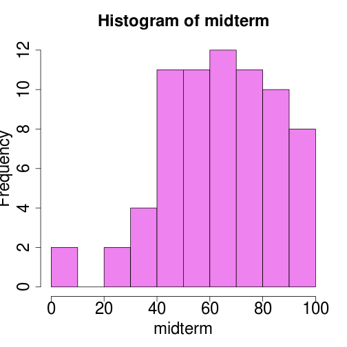

```r
mean(midterm)
```

```
[1] 63.5493
```

```r
median(midterm)
```

```
[1] 64
```

### Midterm distribution

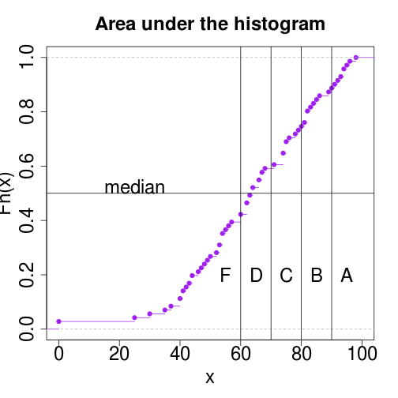

Percent of the class with a \( X \) or above:

```
     [,1]
[1,] "A   11%"
[2,] "B   25%"
[3,] "C   41%"
[4,] "D   58%"
```

### Course grade distribution

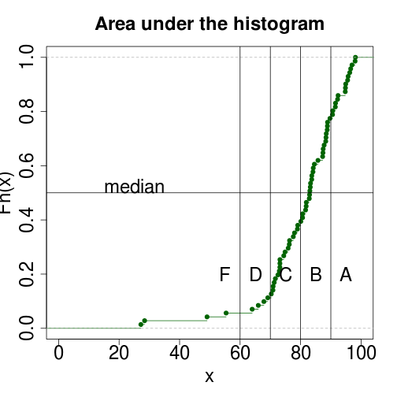

After dropping

- 3 lowest checkpoints
- 1 lowest homework

```
     [,1]
[1,] "A   23%"
[2,] "B   62%"
[3,] "C   89%"
[4,] "D   94%"
```

**No “curve” is needed.**

### Question Breakdown

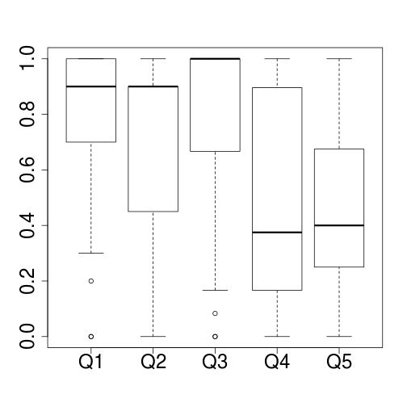

Questions 4 and 5 differentiated the class.

- Homework 4 score had very little power to predict performance
- **Time** seemed to be an issue for **some** students
- **Many students** were simply wrong.

### Moving Forward

**Mid-Quarter Grades**

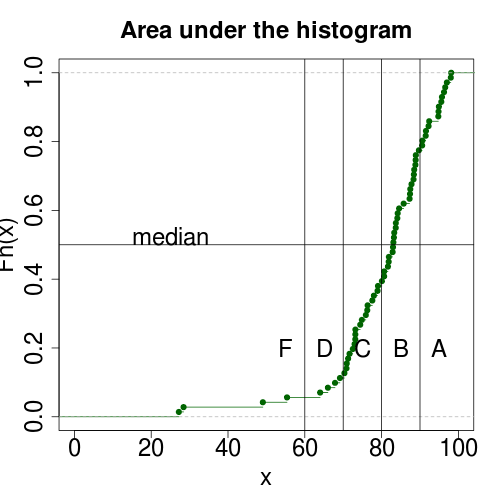

- To determine final exam length I will **triple** the time it took me instead of doubling it.
- You will see something like Q4 and Q5 on the final.
- The final Q4 and Q5 can replace the midterm Q4 and Q5 scores.

### Agenda

1. Midterm (test and quarter!) comments
2. PSA
3. Lecture 14 (covers pp. 160-165)

### PSA - Office hours

I need to cancel **my** office hours this week.

- If you need to meet with me, as always, feel free to send me an email.
- Aaron will still hold his office hours on Thursday.
- (For that matter send Aaron email if you can't make his either.)

### PSA - Intersex Awareness day

From [Emily Quinn](http://www.mtv.com/news/1974481/intersex-awareness-day/) (Animator for [Adventure Time](http://www.cartoonnetwork.com/games/adventuretime/index.html)):

> Being intersex means that you were born with differences in your sexual characteristics — these differences can affect genes, chromosomes, genitalia, reproductive organs, hormones and also things like body hair and how much you sweat.
- [Quinn's AMA](http://www.reddit.com/r/IAmA/comments/2kerur/iam_emily_quinn_and_im_intersex_happy_intersex/) on reddit (yesterday).
- Surprising Fact: Intersex is as common as being a natural redhead (1/20,000).
- For pedagogic reasons, Stat 202 gender is binary.

### Agenda

1. Midterm (test and quarter!) comments
2. PSA
3. Lecture 14 (covers pp. 160-165)

### Height of Adult males

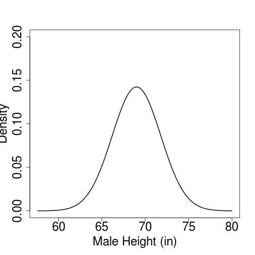

Assume that the height of adult men is normally distributed with a mean of 69 in. and a standard deviation of 2.8 in.

### Height of Adult males

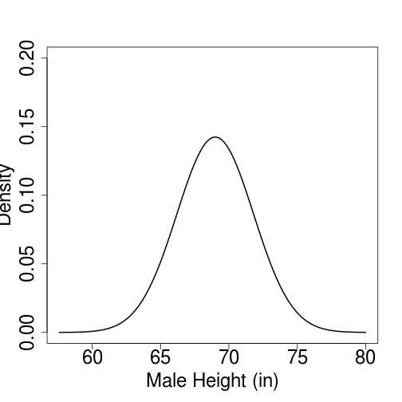

Assume that the height of adult men is normally distributed with a mean of 69 in. and a standard deviation of 2.8 in.

- Randomly select 15 men from the population and measure their heights:

```
67.2 69.5 66.7 73.5 69.9 66.7 70.4 71.1 70.6 68.1 73.2 70.1 67.3 62.8 72.1
```

### Height of Adult males

Assume that the height of adult men is normally distributed with a mean of 69 in and a standard deviation of 2.8 inches.

- Randomly select 15 men from the population and measure their heights:
- Make a histogram of those randomly selected 15 men.

### Height of Adult males

The black density curve represents the **population**.

If we randomly select 15 **different** men from the population we will have a **different** sample.

### Height of Adult males

**First sample**

**Second Sample**

[figure not shown]

### Height of Adult males

**First sample**

First sample mean:

```
[1] 69.3
```

**Second Sample**

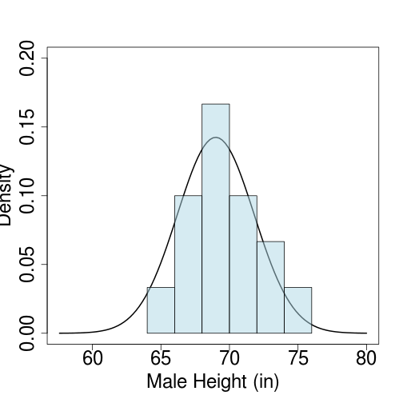

Second sample mean:

```
[1] 69.7
```

### Sample mean of Adult Males

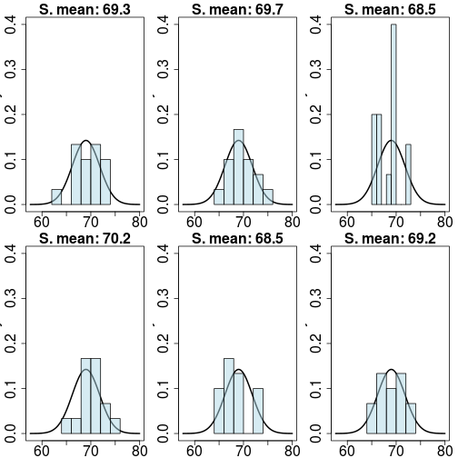

The **population** mean

- always 69 inches.

Each **sample** mean

```
69.3 69.7 68.5 70.2 68.5 69.2
```

- sample means differ depending on the sample
- technical term: **sampling variability**

### Parameters v. statistics

- The population mean is a **parameter**.
  - parameters are numbers that describe (a model of) a population
- The sample mean is a **statistic**
  - statistics are numbers that are computed from a sample

> The goal of **point estimation** is to find a statistic that is a “good” estimate of a parameter

### Example

The length of human pregnancies has a mean of 266 days and a standard deviation of 16 days. A random sample of 9 pregnant women was observed to have a mean pregnancy length of 270 days, with a standard deviation of 14 days. Identify the parameters and accompanying statistics in this situation.

**Parameters**

- mean of 266 days, standard deviation of 16 days

**Statistics**

- sample mean of 270 days, sample standard deviation of 14 days

### Example

If students picked numbers completely at random from the numbers 1 to 20, the proportion of times that the number 7 would be picked is .05. When 15 students picked a number “at random” from 1 to 20, 3 of them picked the number 7. Identify the parameter and accompanying statistic in this situation.

**Parameter**

- proportion is 0.05 (according to the random selection model)

**Statistic**

- sample proportion is 3/15

### Stat 202 focuses on

Population Parameters

Continuous

- Population mean: \( \mu \)
- Population standard deviation: \( \sigma \)

Categorical

- Population proportion: \( p \)

Sample Statistics

Continuous

- Sample mean: \( \bar{x} \)
- Sample standard deviation: \( s \)

Categorical

- Sample proportion: \( \hat{p} \)

### Categorical: Proportions

Approximately 60% of all part-time college students in the United States are female. What would you expect to see in terms of the behavior of a sample proportion of females if random samples of size 20 were taken from the population of all part-time college students?

What is \( p = ? \)

- \( p = .6 \)

What is the **sample size** \( n = ? \)

- \( n = 20 \)

What is the distribution of the *sample proportion* \( \hat{p} \)?

### $$\hat{p} = ? \text{ when } p=.6 \text{ and } n = 20$$

**Step 1**: Draw a sample of 20 part-time college students:

```
F F F M F M M M M F F F M F M F M M F M
```

**Step 2:** Count the number of males and females.

```
 F  M
10 10
```

**Step 3:** Find the sample proportion of females.

```r
10/n
```

```
[1] 0.5
```

### $$\hat{p} = ? \text{ when } p=.6 \text{ and } n = 20$$

**Step 1**: Draw a sample of 20 part-time college students:

```
F M F F M M F M F F F F M F F M M F F F
```

**Step 2:** Count the number of males and females.

```
 F  M
13  7
```

**Step 3:** Find the sample proportion of females.

```r
13/n
```

```
[1] 0.65
```

### Write them down

```
0.50 0.65
```

### Do it again

```
0.50 0.65 0.60
```

### Do this 100 times

```
0.50 0.65 0.60 0.55 0.65 0.45 0.75 0.65 0.80 0.80 0.75 0.75 0.55 0.50 0.35 0.60 0.55 0.65 0.65 0.60 0.50 0.55 0.45 0.55 0.60 0.60 0.60 0.50 0.65 0.70 0.65 0.35 0.65 0.65 0.55 0.70 0.60 0.70 0.70 0.65 0.40 0.45 0.70 0.90 0.85 0.60 0.65 0.65 0.75 0.65 0.65 0.55 0.55 0.45 0.75 0.55 0.65 0.60 0.50 0.55 …
```

### Do this 1,000 times

```
0.50 0.65 0.60 0.55 0.65 0.45 0.75 0.65 0.80 0.80 0.75 0.75 0.55 0.50 0.35 0.60 0.55 0.65 0.65 0.60 0.50 0.55 0.45 0.55 0.60 0.60 0.60 0.50 0.65 0.70 0.65 0.35 0.65 0.65 0.55 0.70 0.60 0.70 0.70 0.65 0.40 0.45 0.70 0.90 0.85 0.60 0.65 0.65 0.75 0.65 0.65 0.55 0.55 0.45 0.75 0.55 0.65 0.60 0.50 0.55 …
```

### Make a histogram

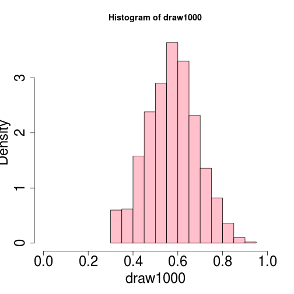

The sample proportion \( \hat{p} \)

- is different for different samples
- has a **sampling distribution**

The **sampling distribution** of a sample proportion is **often approximately normal**.

### Approximately normal (usually)

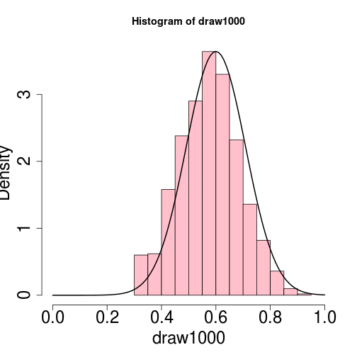

- \( p \) is the population proportion
  - 60% of part-time college students are female
- \( n \) the sample size
  - take a random sample of 20 part-time students

### Approximately normal (when?)

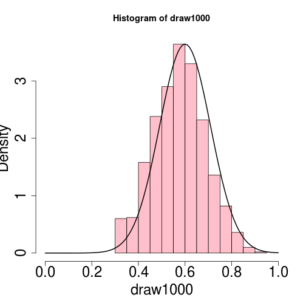

If

\[ np \ge 10 \]

**and**

\[ n(1-p) \ge 10 \]

then \( \hat{p} \) is approximately normal.

Example:  
\( 20 \times .6 = 12 \), but \( 20 \times (.4) = 8 \)

**Not quite normal!**

### Approximately normal (when?)

**Proportion female of 20 students**

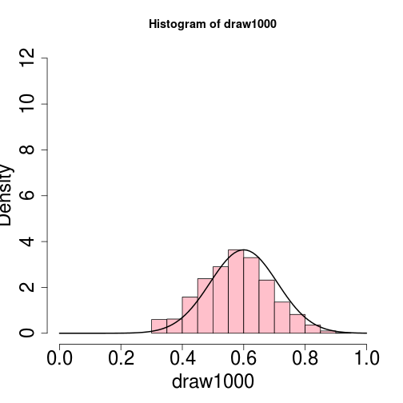

\[ p = .6 \quad n = 20 \]

**Proportion female of 40 students**

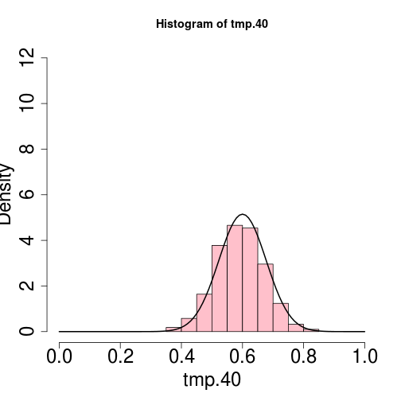

\[ p = .6 \quad n = 40 \]

### Approximately normal (which?)

If \[ \begin{aligned} np & \ge 10 & & \text{and} & n(1-p) \ge 10 \end{aligned} \]

then \( \hat{p} \) is approximately normal:

\[ \hat{p} \sim N\left( p, \frac{p(1-p)}{n} \right) \]

Where the mean and standard deviation of \( \hat{p} \) are:

\[ \begin{aligned} E[\hat{p}] & = p & & & \text{sd}[\hat{p}] & = \sqrt{\frac{p(1-p)}{n}} \end{aligned} \]

As \( n \) increases, \( \hat{p} \) is likely to be **closer** to the population proportion \( \hat{p} \).

### Approximately normal (which?)

**Proportion female of 100 students**

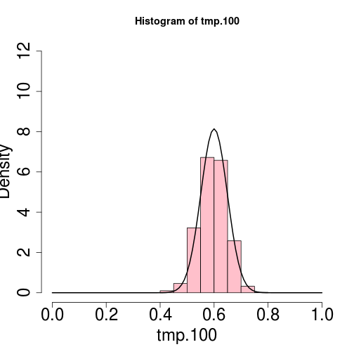

\[ p = .6 \quad n = 100 \]

**Proportion female of 200 students**

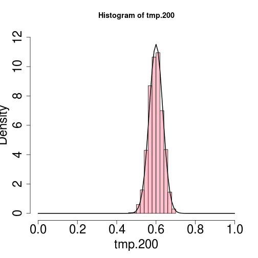

\[ p = .6 \quad n = 200 \]

### An example problem

[In 1998](http://www.registrar.northwestern.edu/academic_records/enrollment_and_graduation_statistics.html) (the most recent data available!) 70% of Northwestern students were white (non-Hispanic), 20% were asian, and 10% were of other ethnicities.

Consider a random sample of 50 Northwestern students. Are the

- sample proportion of white students,
- sample proportion of asian students, and/or
- sample proportion of “other” students

approximately normally distributed?

### An example problem (white)

70% of Northwestern students were white (non-Hispanic), 20% were asian, and 10% were of other ethnicities. Consider random sample of 50 Northwestern students. Is the sample proportion of white students approximately normally distributed?

What are \( p \) and \( n \)?

\( p = .70 \) and \( n= 50 \)

Approximately normal?

\( np = 50 \times .70 = 35 \) and \( n(1-p) = 50 \times .30 = 15 \) both \( \ge 10 \), therefore **yes**

### An example problem (other)

70% of Northwestern students were white (non-Hispanic), 20% were asian, and 10% were of other ethnicities. Consider random sample of 50 Northwestern students. Is the sample proportion of “other” students approximately normally distributed?

What are \( p \) and \( n \)?

\( p = .10 \) and \( n= 50 \)

Approximately normal?

\( np = 50 \times .10 = 5 \) and \( n(1-p) = 50 \times .90 = 45 \) **not both** \( \ge 10 \), therefore **no**

### An example problem (white)

[In 1998](http://www.registrar.northwestern.edu/academic_records/enrollment_and_graduation_statistics.html) (the most recent data available!) 70% of Northwestern students were white (non-Hispanic), 20% were asian, and 10% were of other ethnicities.

There is a 95% chance that the sample proportion of white students will fall between what two values?

- As shown, the sample proportion of white students is approximately normal.
- What are the mean and standard deviation of this approximate normal distribution?

### An example problem (white)

70% of Northwestern students were white (non-Hispanic), 20% were asian, and 10% were of other ethnicities. There is a 95% chance that the sample proportion of white students will fall between what two values?

\( p \), \( n \), and approx normal?: \( p = .70 \), \( n= 50 \), and yes.

Mean of \( \hat{p} \)?

- \( E[ \hat{p} ] = p = .70 \)

SD of \( \hat{p} \)?

- \( \text{sd}[\hat{p}] = \sqrt{\frac{p(1-p)}{n}} = \sqrt{\frac{.7(1-.7)}{50}} = 0.0648 \)

### An example problem (white)

70% of Northwestern students were white (non-Hispanic), 20% were asian, and 10% were of other ethnicities. There is a 95% chance that the sample proportion of white students will fall between what two values?

\( p \), \( n \), and approx. normal?: \( p = .70 \), \( n= 50 \), and yes.

**68/95/99.7 rule:** \[ \begin{aligned} .7 - 2 \times 0.0648 & = .57 & & \text{and} & .7 + 2 \times 0.0648 & = .83 \end{aligned} \]

### An example problem (white)

[In 1998](http://www.registrar.northwestern.edu/academic_records/enrollment_and_graduation_statistics.html) (the most recent data available!) 70% of Northwestern students were white (non-Hispanic), 20% were asian, and 10% were of other ethnicities.

Note: I can ask you **any** normal question.

If we take a sample of 100 students, how likely is it that the sample proportion of white students will fall between 65% and 75%?

Etc.